# Annual Income Classifier

### 4.4.2 Model with subset (Without outliers)

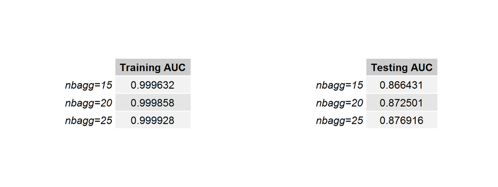

The left and right tables stand for training and testing AUC, respectively, like the previous part. We notice that as `nbagg` going higher, the training AUC is keeping going up towards 1. One the right side, the testing AUC first goes up, too.

Hence, we would like to choose `nbagg = 25` as our final parameters since it has the highest testing AUC. The detailed information about this model will be listed below.

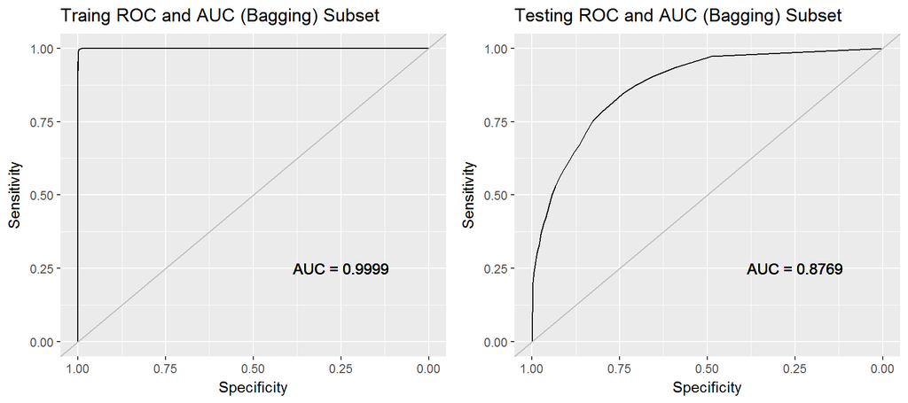

### 4.4.3 Summary of Bagging

In this case, there is one serious problem which we must take a look at. This both `Bagging` models give us over-fitted results. As we know that, when we increase the complexity of models, our traing metric will go better towards being the best while our testing metric will go down first and then go back worse, which is defined as over-fitting. Over-fitting is kind of a general common result if we choose to apply the complicated tree models. In this case, we can choose to lower our model complexity manually to deal with problem.

Also, more tuning parameters like `nbagg=30`, `nbagg=35` or more that we did not attempt may still be tuned and helped us find out the best model.

## 4.5 Random Forest

### 4.5.1 Model with full dataset

Firstly, we would like to build a `Random Forest` model by using training dataset obtained from original dataset (without removing outliers). The training and testing ROC curves and AUCs are also shown below.

Like `Bagging` model, brief summary including basic model information, `ntree`, confusion matrix (cutoff = 0.5), etc will also be listed below.

- Tuning Parameters

Here, we would like to tune the parameters `ntree` and `mtry` here. We will try 500, 1000, and 1500 trees, and 2, 3, 4 numbers of variables at each split. The outputs are listed below. We will find out our best tuning parameters based on their performances.

- The `left` and `right` tables stand for training and testing AUC, respectively.

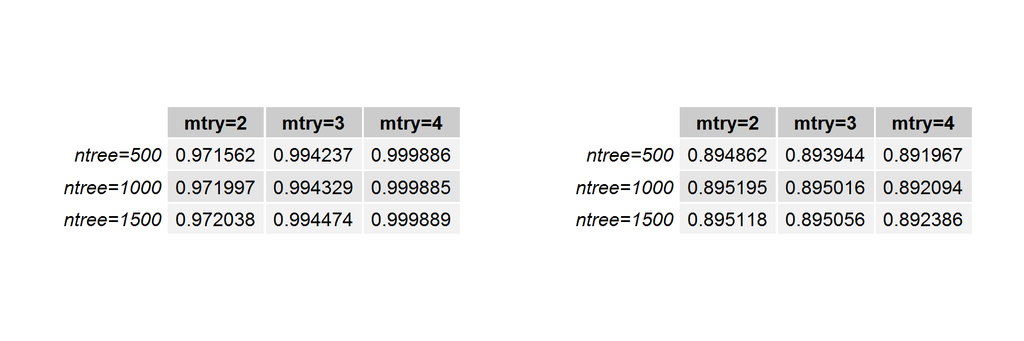

We notice that as `ntree` and `mtry` going higher, the training AUC is keeping going up towards 1. One the right side, the testing AUC first goes up and then drop back down. This results tell us that we need to choose our model parameters wisely, or over-fitting will become a serious problem.

Hence, we would like to choose `mtry=2` and `ntree=1000` as our final parameters based on the tables above. The detailed information about this model will be listed below.

```
##
## Call:
##  randomForest(formula = salary ~ relationship + capital_gain +      age + education + occupation + marital_status + fnlwgt, data = Train_Adult,      ntree = 1000, mtry = 2)
##                Type of random forest: classification
##                      Number of trees: 1000
## No. of variables tried at each split: 2
##
##         OOB estimate of  error rate: 14.54%
## Confusion matrix:
##       <=50K >50K class.error
## <=50K 18478 1253  0.06350413
## >50K   2533 3782  0.40110847
```

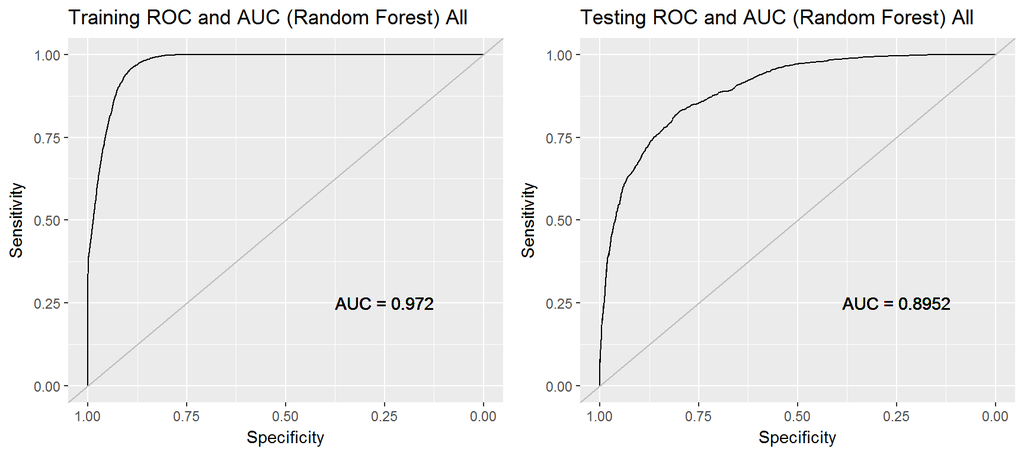

### 4.5.2 Model with subset (Without outliers)

Like the previous part, we will also tune `ntree` and `mtry` here. The choices of these tuning parameters will be set as the same values as previous part.

- The `left` and `right` tables stand for training and testing AUC, respectively.

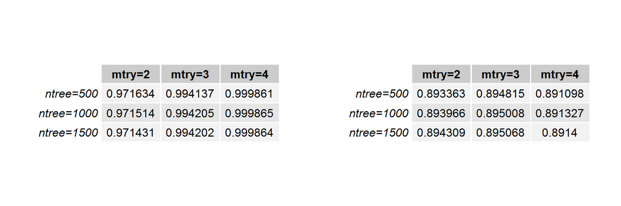

In this case, we notice that potential overfitting still exists like the previous part. Hence, we would like to select `ntree=1500`, and `mtry=3` based on the testing AUC. The detailed result will be shown below.

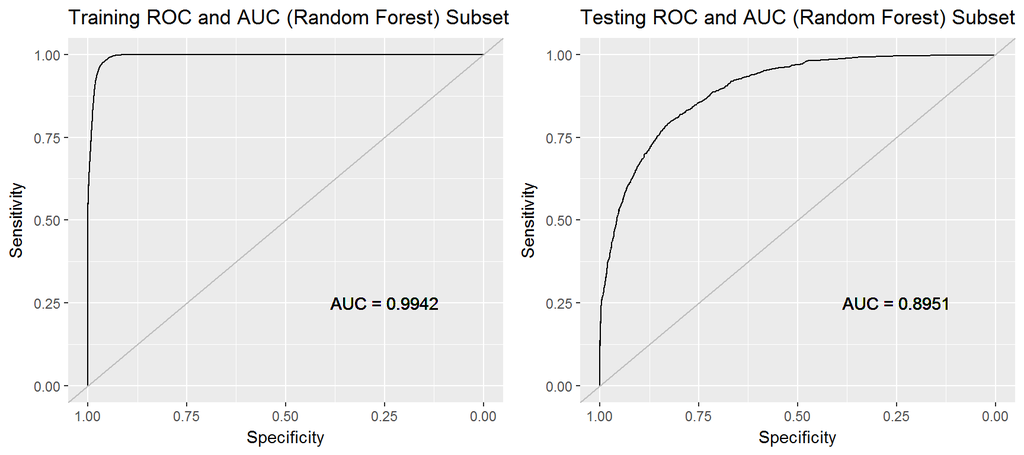

### 4.5.3 Summary of Random Forest

For complicated tree models, over-fitting is one important issue that we cannot ignore. In this case, we can read that over-fitting issue still exists, but luckily it was not as serious as the model of `bagging`. Like what we mentioned in the previous part, we can choose to lower the complexity of our models manually in order to solve this issue.

Also, more tuning parameters that we did not attempt may still be tuned and helped us find out the best model.

# 5 Comparison and Conclusion

## 5.1 Comparison

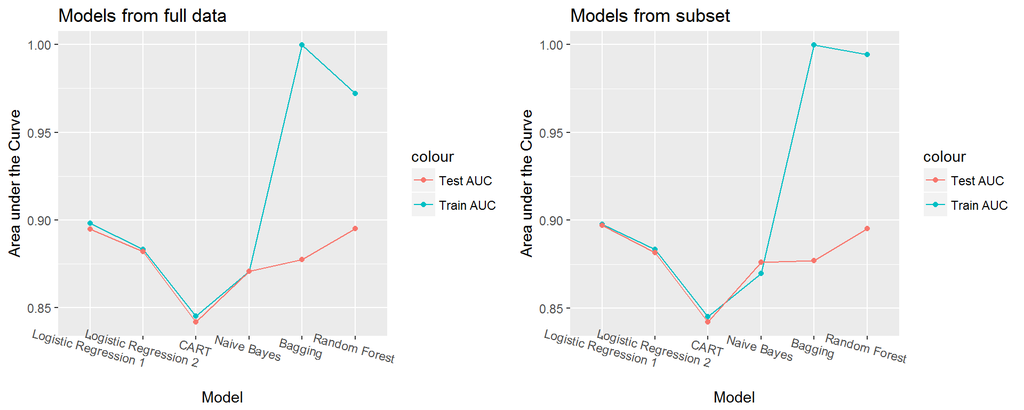

## 5.2 Conclusion

In `5.1` part, we have already compared the AUCs of different methods. The final choice of model should depend on the background and business need of this project.

- Situation 1

If we would like to understand correlationship among predictors and response quantitively and/or make business suggestions based on our model results, `Logistic Regression 1` should be considered as our best choice here. Because we can interpret our results quantitively based on Logistic Regression algorithm, and its performance here is the best among `Logistic Regression`, `CART` and `Naive Bayes` algorithms.

- Situation 2

If we would like to build a black box which can make almost perfect predictions, `Random Forest` should be considered as our best choice here. Because of its most satisfactory overall performance which we discussed in the previous part.

## 5.3 Further thoughts

### 5.3.1 Cross-validation

Cross-validation can be applied here to help us build statistical models. Also, it is a very useful tool to help us prevent or lower the potential overfitting issues.

### 5.3.2 Outliers

In this case, for each algorithm, we chose to build at least one model based on the dataset with and without outliers. The results that we get are basically the same as each other within different methods.

In the second dataset (the one without outliers), we may try to downweight those outliers instead of deleting those points aggressively. Because not all outliers are resulted from data entry error, and some important information may and will be thrown away if we choose to delete those points.

### 5.3.3 Variable fnlwgt

From the description (URL: https://archive.ics.uci.edu/ml/machine-learning-databases/adult/adult.names) of the Adult dataset, we can have access to the brief defination of variable `fnlwgt`. After reading it, we can know that this variable is created by considering information including but not limited to demographic characters and different states, which result in potential multicollinearity among predictors, such as `race`, `sex`, `fnlwgt`, etc. For some particular methods, like `Logistic Regression` and `Naive Bayes`, multicollinearity may cause serious problems and make our predictons less trustable.

Hence, variable `fnlwgt` or the transformation of `fnlwgt` being treated as the weight rather than one predictor here may help increase the performance of our new models and make our models more persuasive.